*AI_CA5_PHASE2*

*Navid Dehban(810198390)*

# Importing & loading data

```python
import numpy as np
import pandas as pd
import tensorflow as tf
import matplotlib.pyplot as plt
import cv2
import zipfile
import seaborn as sns
from tensorflow.keras.preprocessing.image import ImageDataGenerator
from tensorflow.keras import layers
from tensorflow.keras import *
from google.colab.patches import cv2_imshow
from google.colab import drive
from IPython.display import Image, display
from sklearn.metrics import classification_report
```

```python
drive.mount('/content/drive')
```

```python
path = '/content/drive/MyDrive/dataset.zip'
zip_object = zipfile.ZipFile(file = path , mode ='r')
zip_object.extractall('./')
zip_object.close()
```

**Preprocessing**

```python
dataset_generator_train = ImageDataGenerator()
train_data = dataset_generator_train.flow_from_directory(directory='/content/dataset/train',target_size=(32,32),color_mode='grayscale',batch_size= 32,class_mode='categorical')
test_data = dataset_generator_train.flow_from_directory(directory='/content/dataset/test',target_size=(32,32),color_mode='grayscale',batch_size= 32,class_mode='categorical')
```

```
Found 1945 images belonging to 4 classes.
Found 833 images belonging to 4 classes.
```

```python
classes = np.unique(train_data.classes, return_counts = True)
classes_name = train_data.class_indices
print('train data :')
print("names of classes: ", classes_name.keys())
print("number of classes of train data: ", classes)
print('')
classes = np.unique(test_data.classes, return_counts = True)
classes_name = test_data.class_indices
print('test data :')
print("names of classes: ", classes_name.keys())
print("number of classes of train data: ", classes)
```

```
train data :
names of classes:  dict_keys(['bald_eagle', 'elk', 'racoon', 'raven'])
number of classes of train data:  (array([0, 1, 2, 3], dtype=int32), array([521, 462, 507, 455]))

test data :
names of classes:  dict_keys(['bald_eagle', 'elk', 'racoon', 'raven'])
number of classes of train data:  (array([0, 1, 2, 3], dtype=int32), array([223, 198, 217, 195]))
```

```
{'bald_eagle': 0, 'elk': 1, 'racoon': 2, 'raven': 3}
```

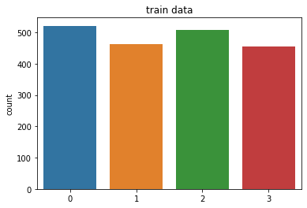

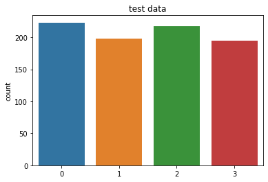

```python
plotc = sns.countplot(train_data.classes)
plotc.set_title("train data")
plt.figure()
plotc = sns.countplot(test_data.classes)
plotc.set_title("test data")
print(train_data.class_indices)
```

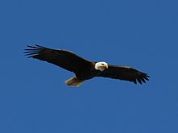

```
bald_eagle
```

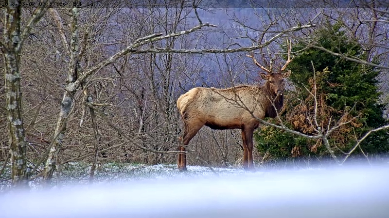

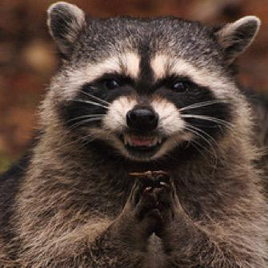

```
elk
racoon
```

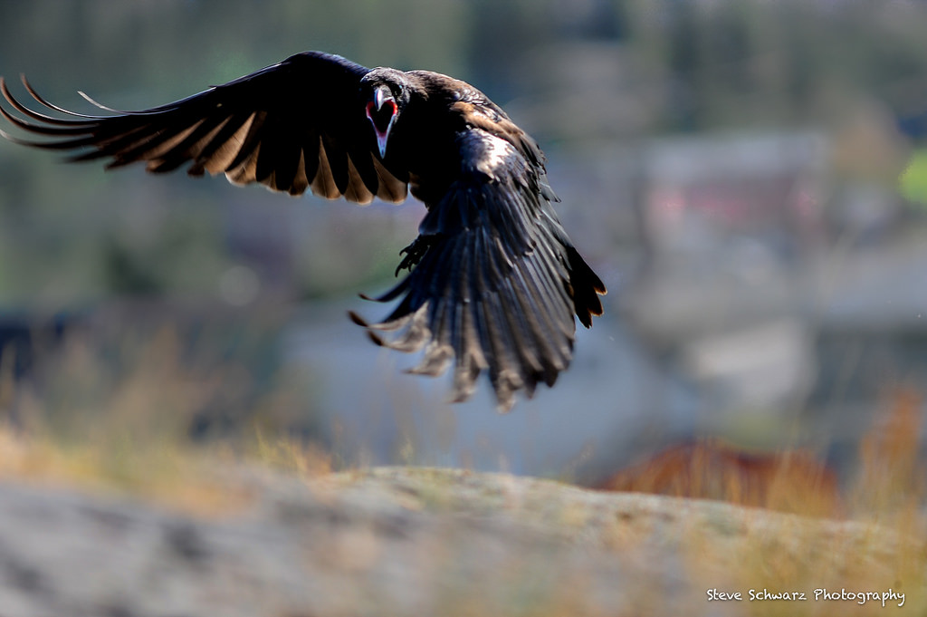

```
raven
```

```python
bald_eagle =  "/content/dataset/test/bald_eagle/0a6bf3fa0a0d17aed4.jpg"
elk =         "/content/dataset/test/elk/0bd65ab8745e0fd20c.jpg"
racoon =      "/content/dataset/test/racoon/0b46a37d4b204a5a73.jpg"
raven =       "/content/dataset/test/raven/0ac4bb35a3a0c0f15c.jpg"

display(Image(filename=bald_eagle, width=256, height=256))
print("bald_eagle")
display(Image(filename=elk, width=256, height=256))
print("elk")
display(Image(filename=racoon, width=256, height=256))
print("racoon")
display(Image(filename=raven, width=256, height=256))
print("raven")
```

```python
data_gen = ImageDataGenerator(rescale=1./255, validation_split=0.1)
train_dataset = data_gen.flow_from_directory(directory='/content/dataset/train', target_size=(32,32),color_mode='grayscale',batch_size= 32,class_mode='categorical',subset='training')
val_dataset = data_gen.flow_from_directory(directory='/content/dataset/train', target_size=(32,32),color_mode='grayscale',batch_size= 32,class_mode='categorical',subset='validation')
```

```
Found 1752 images belonging to 4 classes.
Found 193 images belonging to 4 classes.
```

# Nueral network

```python
input = layers.Input(shape=(32,32,1))
out   = layers.Flatten()(input)
out   = layers.Dense(2048, activation = 'relu')(out)
out   = layers.Dense(1024, activation = 'relu')(out)
out   = layers.Dense(4, activation = 'softmax')(out)
model = models.Model(inputs = input, outputs = out)
model.compile(optimizer = optimizers.SGD(learning_rate = 0.01), loss = 'categorical_crossentropy', metrics = ["accuracy"])
model.summary()
```

```
Model: "model_9"
_________________________________________________________________
 Layer (type)                Output Shape              Param #
=================================================================
 input_10 (InputLayer)       [(None, 32, 32, 1)]       0

 flatten_9 (Flatten)         (None, 1024)              0

 dense_27 (Dense)            (None, 2048)              2099200

 dense_28 (Dense)            (None, 1024)              2098176

 dense_29 (Dense)            (None, 4)                 4100

=================================================================
Total params: 4,201,476
Trainable params: 4,201,476
Non-trainable params: 0
_________________________________________________________________
```

```python
  hist = model.fit(train_dataset, validation_data=val_dataset, epochs=10)
```

```python
y_pred = np.argmax(model.predict(train_dataset, 1), axis = 1)
y_true = np.array(train_dataset.labels)
print(classification_report(y_true, y_pred))
```

```
              precision    recall  f1-score   support

           0       0.24      0.19      0.21       469
           1       0.27      0.30      0.28       416
           2       0.26      0.35      0.30       457
           3       0.21      0.16      0.18       410

    accuracy                           0.25      1752
   macro avg       0.24      0.25      0.24      1752
weighted avg       0.24      0.25      0.24      1752
```

refrence: https://scikit-learn.org/stable/modules/generated/sklearn.metrics.classification_report.html

# Ordering data

```python
def NN(type_optimizer, learnig_rate, momentum_, epochs_):

  if type_optimizer == 'sgd':
    input = layers.Input(shape=(32,32,1))
    out = layers.Flatten()(input)
    out = layers.Dense(4096, activation = 'relu')(out)
    out = layers.Dense(1024, activation = 'relu')(out)
    out = layers.Dense(4, activation = 'softmax')(out)
    model = models.Model(inputs = input, outputs = out)
    model.compile(optimizer = optimizers.SGD(learning_rate = learnig_rate, momentum= momentum_), loss = 'categorical_crossentropy', metrics = ["accuracy"])
    hist = model.fit(train_dataset, epochs = epochs_, validation_data = val_dataset)
    y_pred = np.argmax(model.predict(test_data, 1), axis = 1)
    y_true = np.array(test_data.labels)
    print(classification_report(y_true, y_pred))
    print(model.summary())
    plt.figure()
    plt.plot(hist.history['val_accuracy'])
    plt.title("accuracy")
    plt.figure()
    plt.plot(hist.history['val_loss'])
    plt.title("loss")

  if type_optimizer == 'adam':
    input = layers.Input(shape=(32,32,1))
    out = layers.Flatten()(input)
    out = layers.Dense(4096, activation = 'relu')(out)
    out = layers.Dense(1024, activation = 'relu')(out)
    out = layers.Dense(4, activation = 'softmax')(out)
    model = models.Model(inputs = input, outputs = out)
    model.compile(optimizer = optimizers.Adam(learning_rate = learnig_rate), loss = 'categorical_crossentropy', metrics = ["accuracy"])
    hist = model.fit(train_dataset, epochs = epochs_, validation_data = val_dataset)
    y_pred = np.argmax(model.predict(test_data, 1), axis = 1)
    y_true = np.array(test_data.labels)
    print(classification_report(y_true, y_pred))
    print(model.summary())
    plt.figure()
    plt.plot(hist.history['val_accuracy'])
    plt.title("accuracy")
    plt.figure()
    plt.plot(hist.history['val_loss'])
    plt.title("loss")

  if type_optimizer == 'loss':
    input = layers.Input(shape=(32,32,1))
    out = layers.Flatten()(input)
    out = layers.Dense(4096, activation = 'relu')(out)
    out = layers.Dense(1024, activation = 'relu')(out)
    out = layers.Dense(4, activation = 'softmax')(out)
    model = models.Model(inputs = input, outputs = out)
    model.compile(optimizer = optimizers.Adam(learning_rate = learnig_rate), loss = 'mean_squared_error', metrics = ["accuracy"])
    hist = model.fit(train_dataset, epochs = epochs_, validation_data = val_dataset)
    y_pred = np.argmax(model.predict(test_data, 1), axis = 1)
    y_true = np.array(test_data.labels)
    print(classification_report(y_true, y_pred))
    print(model.summary())
    plt.figure()
    plt.plot(hist.history['val_accuracy'])
    plt.title("accuracy")
    plt.figure()
    plt.plot(hist.history['val_loss'])
    plt.title("loss")

  if type_optimizer == 'regular_p1':
    input = layers.Input(shape=(32,32,1))
    out = layers.Flatten()(input)
    out = layers.Dense(4096, activation = 'relu', kernel_regularizer=regularizers.l2(0.0001))(out)
    out = layers.Dense(1024, activation = 'relu', kernel_regularizer=regularizers.l2(0.0001))(out)
    out = layers.Dense(4, activation = 'softmax', kernel_regularizer=regularizers.l2(0.0001))(out)
    model = models.Model(inputs = input, outputs = out)
    model.compile(optimizer = optimizers.Adam(learning_rate = learnig_rate), loss = 'categorical_crossentropy', metrics = ["accuracy"])
    hist = model.fit(train_dataset, epochs = epochs_, validation_data = val_dataset)
    y_pred = np.argmax(model.predict(test_data, 1), axis = 1)
    y_true = np.array(test_data.labels)
    print(classification_report(y_true, y_pred))
    print(model.summary())
    plt.figure()
    plt.plot(hist.history['val_accuracy'])
    plt.title("accuracy")
    plt.figure()
    plt.plot(hist.history['val_loss'])
    plt.title("loss")

  if type_optimizer == 'regular_p2':
    input = layers.Input(shape=(32,32,1))
    out = layers.Flatten()(input)
    out = layers.Dense(4096, activation = 'relu')(out)
    out = layers.Dropout(rate=0.1)(out)
    out = layers.Dense(1024, activation = 'relu')(out)
    out = layers.Dropout(rate=0.1)(out)
    out = layers.Dense(4, activation = 'softmax')(out)
    model = models.Model(inputs = input, outputs = out)
    model.compile(optimizer = optimizers.Adam(learning_rate = learnig_rate), loss = 'categorical_crossentropy', metrics = ["accuracy"])
    hist = model.fit(train_dataset, epochs = epochs_, validation_data = val_dataset)
    y_pred = np.argmax(model.predict(test_data, 1), axis = 1)
    y_true = np.array(test_data.labels)
    print(classification_report(y_true, y_pred))
    print(model.summary())
    plt.figure()
    plt.plot(hist.history['val_accuracy'])
    plt.title("accuracy")
    plt.figure()
    plt.plot(hist.history['val_loss'])
    plt.title("loss")
```

⭕**momentum:**

SGD class Gradient descent (with momentum) optimizer. Update rule for parameter w with gradient g when momentum is 0:

w = w - learning_rate * g

Update rule when momentum is larger than 0:

velocity = momentum *velocity - learning_rate* g

w = w + velocity

float hyperparameter >= 0 that accelerates gradient descent in the relevant direction and dampens oscillations. Defaults to 0, i.e., vanilla gradient descent.

with a proper momentum we can scape from local extermoms, but if the momentum is very high we will loss the optimal values.momentum is as same as steps in search.

```
              precision    recall  f1-score   support

           0       0.25      0.17      0.20       223
           1       0.24      0.21      0.22       198
           2       0.29      0.34      0.31       217
           3       0.20      0.27      0.23       195

    accuracy                           0.24       833
   macro avg       0.24      0.24      0.24       833
weighted avg       0.25      0.24      0.24       833

Model: "model_10"
_________________________________________________________________
 Layer (type)                Output Shape              Param #
=================================================================
 input_11 (InputLayer)       [(None, 32, 32, 1)]       0

 flatten_10 (Flatten)        (None, 1024)              0

 dense_30 (Dense)            (None, 4096)              4198400

 dense_31 (Dense)            (None, 1024)              4195328

 dense_32 (Dense)            (None, 4)                 4100

=================================================================
Total params: 8,397,828
Trainable params: 8,397,828
Non-trainable params: 0
_________________________________________________________________
None
```

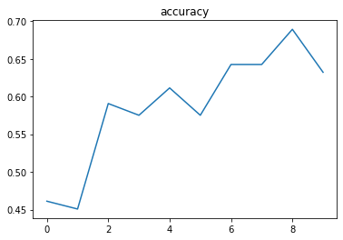

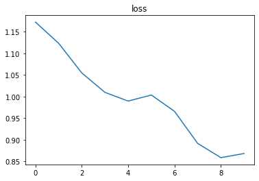

```python
NN(type_optimizer = 'sgd', learnig_rate = 0.01, momentum_ = 0.5, epochs_ = 10)
```

```
              precision    recall  f1-score   support

           0       0.26      0.08      0.12       223
           1       0.27      0.33      0.30       198
           2       0.26      0.25      0.26       217
           3       0.24      0.39      0.30       195

    accuracy                           0.26       833
   macro avg       0.26      0.26      0.24       833
weighted avg       0.26      0.26      0.24       833

Model: "model_11"
_________________________________________________________________
 Layer (type)                Output Shape              Param #
=================================================================
 input_12 (InputLayer)       [(None, 32, 32, 1)]       0

 flatten_11 (Flatten)        (None, 1024)              0

 dense_33 (Dense)            (None, 4096)              4198400

 dense_34 (Dense)            (None, 1024)              4195328

 dense_35 (Dense)            (None, 4)                 4100

=================================================================
Total params: 8,397,828
Trainable params: 8,397,828
Non-trainable params: 0
_________________________________________________________________
None
```

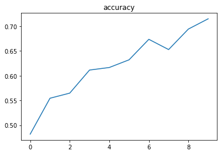

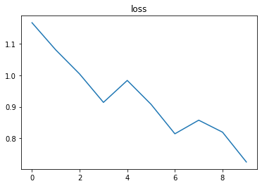

```python
NN(type_optimizer = 'sgd', learnig_rate = 0.01, momentum_ = 0.9, epochs_ = 10)
```

**Adam:**

Adam's algorithm is faster than sgd but sgd is more accurate than adam.

```
              precision    recall  f1-score   support

           0       0.25      0.26      0.26       223
           1       0.20      0.11      0.14       198
           2       0.25      0.34      0.29       217
           3       0.21      0.23      0.22       195

    accuracy                           0.24       833
   macro avg       0.23      0.23      0.23       833
weighted avg       0.23      0.24      0.23       833

Model: "model_12"
_________________________________________________________________
 Layer (type)                Output Shape              Param #
=================================================================
 input_13 (InputLayer)       [(None, 32, 32, 1)]       0

 flatten_12 (Flatten)        (None, 1024)              0

 dense_36 (Dense)            (None, 4096)              4198400

 dense_37 (Dense)            (None, 1024)              4195328

 dense_38 (Dense)            (None, 4)                 4100

=================================================================
Total params: 8,397,828
Trainable params: 8,397,828
Non-trainable params: 0
_________________________________________________________________
None
```

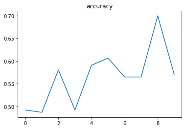

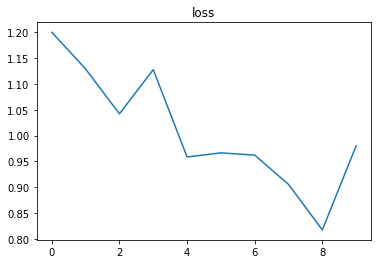

```python
NN(type_optimizer = 'adam', learnig_rate = 0.001, momentum_ = 0.9, epochs_ = 10)
```

⭕**Epoch:**

An epoch is defined as a single training iteration of all batches in both forward and back propagation. This means 1 epoch is a single forward and backward pass of the entire input data.

The number of epochs you would use to train your network can be chosen by you. It’s highly likely that more number of epochs would show higher accuracy of the network, however, it would also take longer for the network to converge. Also you must take care that if the number of epochs are too high, the network might be over-fit.

solution for over-fitting: Dropout – Dropout is a regularization technique which prevents over-fitting of the network. As the name suggests, during training a certain number of neurons in the hidden layer is randomly dropped. This means that the training happens on several architectures of the neural network on different combinations of the neurons. You can think of drop out as an ensemble technique, where the output of multiple networks is then used to produce the final output.

```
              precision    recall  f1-score   support

           0       0.29      0.26      0.27       223
           1       0.29      0.14      0.19       198
           2       0.23      0.16      0.19       217
           3       0.23      0.48      0.31       195

    accuracy                           0.25       833
   macro avg       0.26      0.26      0.24       833
weighted avg       0.26      0.25      0.24       833

Model: "model_13"
_________________________________________________________________
 Layer (type)                Output Shape              Param #
=================================================================
 input_14 (InputLayer)       [(None, 32, 32, 1)]       0

 flatten_13 (Flatten)        (None, 1024)              0

 dense_39 (Dense)            (None, 4096)              4198400

 dense_40 (Dense)            (None, 1024)              4195328

 dense_41 (Dense)            (None, 4)                 4100

=================================================================
Total params: 8,397,828
Trainable params: 8,397,828
Non-trainable params: 0
_________________________________________________________________
None
```

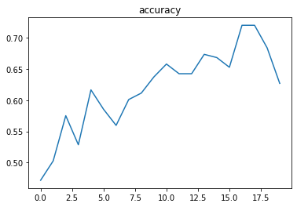

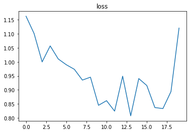

```python
NN(type_optimizer = 'adam', learnig_rate = 0.001, momentum_ = 0.9, epochs_ = 20)
```

⭕**Loss function:**

mse is not proper for binary form data.also when we use mse we assume that our data is relesed from a normal distrbution bit in image classification is not.

```
              precision    recall  f1-score   support

           0       0.00      0.00      0.00       223
           1       0.24      1.00      0.38       198
           2       0.00      0.00      0.00       217
           3       0.00      0.00      0.00       195

    accuracy                           0.24       833
   macro avg       0.06      0.25      0.10       833
weighted avg       0.06      0.24      0.09       833

Model: "model_15"
_________________________________________________________________
 Layer (type)                Output Shape              Param #
=================================================================
 input_16 (InputLayer)       [(None, 32, 32, 1)]       0

 flatten_15 (Flatten)        (None, 1024)              0

 dense_45 (Dense)            (None, 4096)              4198400

 dense_46 (Dense)            (None, 1024)              4195328

 dense_47 (Dense)            (None, 4)                 4100

=================================================================
Total params: 8,397,828
Trainable params: 8,397,828
Non-trainable params: 0
_________________________________________________________________
None
```

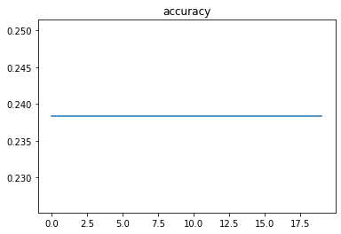

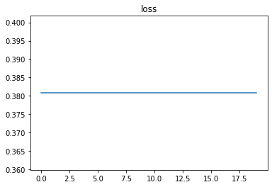

```python
NN(type_optimizer = 'loss', learnig_rate = 0.001, momentum_ = 0.9, epochs_ = 20)
```

⭕**Regularization:**

with l2 regularization we can prevent over-fitting by keeping weights in small values.

```python
NN(type_optimizer = 'regular_p1', learnig_rate = 0.001, momentum_ = 0.9, epochs_ = 20)
```

[output not shown]

⭕**Drop out:**

in drop out condition we will remove some of our connections randomly, with this process we are preventing over-fitting.

```
              precision    recall  f1-score   support

           0       0.27      0.24      0.25       223
           1       0.22      0.15      0.18       198
           2       0.28      0.27      0.28       217
           3       0.24      0.35      0.28       195

    accuracy                           0.25       833
   macro avg       0.25      0.25      0.25       833
weighted avg       0.25      0.25      0.25       833

Model: "model_16"
_________________________________________________________________
 Layer (type)                Output Shape              Param #
=================================================================
 input_17 (InputLayer)       [(None, 32, 32, 1)]       0

 flatten_16 (Flatten)        (None, 1024)              0

 dense_48 (Dense)            (None, 4096)              4198400

 dropout (Dropout)           (None, 4096)              0

 dense_49 (Dense)            (None, 1024)              4195328

 dropout_1 (Dropout)         (None, 1024)              0

 dense_50 (Dense)            (None, 4)                 4100

=================================================================
Total params: 8,397,828
Trainable params: 8,397,828
Non-trainable params: 0
_________________________________________________________________
None
```

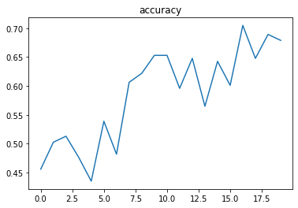

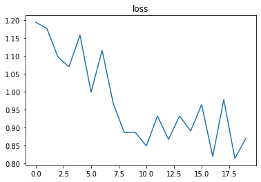

```python
NN(type_optimizer = 'regular_p2', learnig_rate = 0.001, momentum_ = 0.9, epochs_ = 20)
```

# Bonus

```python
input = layers.Input(shape=(32,32,1))
out = layers.Flatten()(input)
out = layers.Dense(10000, activation = 'relu')(out)
out = layers.Dense(2, activation = 'relu')(out)
out = layers.Dense(4, activation = 'softmax')(out)
model = models.Model(inputs = input, outputs = out)
model.compile(optimizer = optimizers.SGD(learning_rate = learning_rate, momentum= momentum_), loss = 'categorical_crossentropy', metrics = ["accuracy"])
hist = model.fit(train_dataset, epochs = epochs_, validation_data = val_dataset)
y_pred = np.argmax(model.predict(test_data, 1), axis = 1)
y_true = np.array(test_data.labels)
print(classification_report(y_true, y_pred))
print(model.summary())
plt.figure()
plt.plot(hist.history['val_accuracy'])
plt.title("accuracy")
plt.figure()
plt.plot(hist.history['val_loss'])
plt.title("loss")
```

[output not shown]